# *Data Cleaning*

## **The data is not always clean so it is necessary to clean the data before you analyze it.**

## There are multiple data problems which can cause data to be messy and make it difficult to analyze.

## The data used in this exercise has common data problems such as

## 1. Inconsistent column names

## 2. Data type of columns

## 3. Missing Data

## 4. Untidy Data

```python
%matplotlib inline

#'%matplotlib inline' sets the backend of matplotlib to the 'inline' backend.
#With this backend, the output of plotting commands is displayed inline within frontends like the Jupyter notebook

import pandas as pd
import matplotlib.pyplot as plt
import seaborn as sns
import os
from matplotlib import pyplot

sns.set(style='ticks', context='talk')

#set() is a Seaborn function for proper Visualisations of graphs and we have used style ='ticks' and context='talks'

oil = pd.read_csv("/Users/saurabhkarambalkar/Downloads/Oil_Prices.csv")
oil.head()
```

|  | Date | Open | High | Low | Last | Change | Settle | Volume | Previous Day Open Interest |
| --- | --- | --- | --- | --- | --- | --- | --- | --- | --- |
| 0 | 10/10/2017 | 49.55 | 51.06 | 49.54 | 50.94 | 1.34 | 50.92 | 641402 | 407051.0 |
| 1 | 10/9/2017 | 49.25 | 49.79 | 49.13 | 49.56 | 0.29 | 49.58 | 487932 | 453631.0 |
| 2 | 10/6/2017 | 50.75 | 50.82 | 49.10 | 49.25 | 1.50 | 49.29 | 720752 | 495395.0 |
| 3 | 10/5/2017 | 49.88 | 51.22 | 49.85 | 50.75 | 0.81 | 50.79 | 649264 | 511107.0 |
| 4 | 10/4/2017 | 50.16 | 50.67 | 49.76 | 49.90 | 0.44 | 49.98 | 596897 | 513316.0 |

#### Now we will start to resolve data problems described above one by one.

## 1. Inconsistent column names

#### Sometimes the column names in our data can have bad characters or inconvinient names so we need to resolve it before we begin.

#### If you observe the above output, it is difficult to know whether 'Previous Day Open Interest' is one column or each one is different and hence it is necessary that we rename it.

#### We will use the below function to first check the names of all columns and clearify our doubt on the last column/columns.

```python
#df.columns will fetch you the names of all columns present in your data

oil.columns
```

```
Index(['Date', 'Open', 'High', 'Low', 'Last', 'Change', 'Settle', 'Volume',
       'Previous Day Open Interest'],
      dtype='object')
```

#### So it is clear from above result that 'Previous Day Open Interest' is one single column and each one is not a different column.

#### We now rename the column using the below code.

```python
#df.rename will rename the columns treating it as a dictionary

oil = oil.rename(columns = {'Settle':'Final', 'Previous Day Open Interest':'OpenInterest'})
oil.head()

#df.head function will display the top 5 (default) values from data
```

|  | Date | Open | High | Low | Last | Change | Final | Volume | OpenInterest |
| --- | --- | --- | --- | --- | --- | --- | --- | --- | --- |
| 0 | 10/10/2017 | 49.55 | 51.06 | 49.54 | 50.94 | 1.34 | 50.92 | 641402 | 407051.0 |
| 1 | 10/9/2017 | 49.25 | 49.79 | 49.13 | 49.56 | 0.29 | 49.58 | 487932 | 453631.0 |
| 2 | 10/6/2017 | 50.75 | 50.82 | 49.10 | 49.25 | 1.50 | 49.29 | 720752 | 495395.0 |
| 3 | 10/5/2017 | 49.88 | 51.22 | 49.85 | 50.75 | 0.81 | 50.79 | 649264 | 511107.0 |
| 4 | 10/4/2017 | 50.16 | 50.67 | 49.76 | 49.90 | 0.44 | 49.98 | 596897 | 513316.0 |

#### From the above result we see that the column 'OpenInterest' has its data type unnecessarily as float. The next data problem we are going to study is data type of columns so let us fix it.

## 2. Data Types of Columns

#### Having wrong data type assigned to our data present in that particular column can signal the presence of unexpected data values. Thus it becomes necessary to assign proper data types to all columns of our data.

#### Using the code below we will determine the data types of all columns and also the missing values.

```python
#df.info function will fetch the data types of all columns with missing values.

oil.info()
```

```
<class 'pandas.core.frame.DataFrame'>
RangeIndex: 8677 entries, 0 to 8676
Data columns (total 9 columns):
Date            8677 non-null object
Open            8677 non-null float64
High            8677 non-null float64
Low             8677 non-null float64
Last            8677 non-null float64
Change          918 non-null float64
Final           8677 non-null float64
Volume          8677 non-null int64
OpenInterest    8676 non-null float64
dtypes: float64(7), int64(1), object(1)
memory usage: 610.2+ KB
```

#### From the above result, it is clearly seen that the data type of 'OpenInterest' is float64 which we now change to integer.

```python
#We use pd.to_numeric function to change the data type to integer


oil.OpenInterest = pd.to_numeric(oil.OpenInterest, errors='coerce')
oil = oil.dropna(subset=['OpenInterest'])
oil.OpenInterest = oil.OpenInterest.astype(int)
oil.head()
```

|  | Date | Open | High | Low | Last | Change | Final | Volume | OpenInterest |
| --- | --- | --- | --- | --- | --- | --- | --- | --- | --- |
| 0 | 10/10/2017 | 49.55 | 51.06 | 49.54 | 50.94 | 1.34 | 50.92 | 641402 | 407051 |
| 1 | 10/9/2017 | 49.25 | 49.79 | 49.13 | 49.56 | 0.29 | 49.58 | 487932 | 453631 |
| 2 | 10/6/2017 | 50.75 | 50.82 | 49.10 | 49.25 | 1.50 | 49.29 | 720752 | 495395 |
| 3 | 10/5/2017 | 49.88 | 51.22 | 49.85 | 50.75 | 0.81 | 50.79 | 649264 | 511107 |
| 4 | 10/4/2017 | 50.16 | 50.67 | 49.76 | 49.90 | 0.44 | 49.98 | 596897 | 513316 |

#### We can observe that there are 8677 rows and 9 columns in total. But the columns 'Change' and 'OpenInterest' have some NAN and missing values missing in them.

## 3. Missing Data

#### Missing Data in our data set will make it difficult to predict or analyse it. So it becomes necessary to fix the missing values problem before we start to analyse it.

#### We will first deal with the column 'Change' which has NAN values which we need to fix.

#### Frequency counts is useful way in exploratory data analysis which we use below.

```python
#df.column.value_counts is frequency count function which will give us the entire view of data and its repetition

oil.Change.value_counts(dropna=False).head()

#We assign dropna=False so that the NAN values are not excluded
```

```
NaN      7758
 0.27      14
 0.19      12
 0.11      12
 0.59      11
Name: Change, dtype: int64
```

#### So we see that there are 7758 NAN values in our data which we can assign to zero but that would make our data inconsistent so to avoid that we set it to the mean value.

#### We will have a look at the mean value using following function.

```python
#df.describe function gives the summary of our data as follows

oil.describe()
```

|  | Open | High | Low | Last | Change | Final | Volume | OpenInterest |
| --- | --- | --- | --- | --- | --- | --- | --- | --- |
| count | 8676.000000 | 8676.000000 | 8676.000000 | 8676.000000 | 918.000000 | 8676.000000 | 8.676000e+03 | 8676.000000 |
| mean | 42.042961 | 42.608751 | 41.448732 | 42.045953 | 0.912320 | 42.046070 | 1.331491e+05 | 137865.271093 |
| std | 28.910964 | 29.283222 | 28.489759 | 28.904902 | 0.778164 | 28.904921 | 1.604473e+05 | 127291.969189 |
| min | 10.000000 | 11.020000 | 9.750000 | 10.420000 | 0.010000 | 10.420000 | 0.000000e+00 | 0.000000 |
| 25% | 19.780000 | 19.950000 | 19.580000 | 19.770000 | 0.330000 | 19.770000 | 3.150975e+04 | 48674.500000 |
| 50% | 29.180000 | 29.450000 | 28.880000 | 29.200000 | 0.715000 | 29.205000 | 6.245750e+04 | 91324.000000 |
| 75% | 59.700000 | 60.452500 | 58.750000 | 59.660000 | 1.287500 | 59.682500 | 2.056968e+05 | 200924.000000 |
| max | 145.190000 | 147.270000 | 143.220000 | 145.290000 | 7.540000 | 145.290000 | 1.282869e+06 | 642793.000000 |

#### We assign mean value of column 'Change' to the NAN values using df.fillna function and will again verify it using frequency count.

```python
#df.column.fillna function is used to fill NA values

oil.Change = oil.Change.fillna(oil.Change.mean())

#We again use frequency count

oil.Change.value_counts(dropna=False)
```

```
0.91232    7758
0.27000      14
0.11000      12
0.19000      12
0.59000      11
0.54000      11
0.66000      11
0.29000      10
0.07000      10
1.14000      10
0.14000      10
0.34000      10
0.70000       9
0.02000       9
0.06000       9
1.00000       9
0.09000       9
0.56000       9
0.17000       9
0.39000       9
0.67000       8
0.46000       8
1.07000       8
0.21000       8
0.33000       8
0.72000       8
0.41000       8
0.04000       8
0.43000       8
1.09000       8
           ...
2.17000       1
2.74000       1
3.08000       1
1.66000       1
1.95000       1
4.40000       1
1.93000       1
1.38000       1
1.67000       1
1.87000       1
2.05000       1
3.56000       1
2.88000       1
1.65000       1
3.48000       1
3.71000       1
2.01000       1
2.33000       1
2.62000       1
1.70000       1
2.27000       1
1.83000       1
0.90000       1
2.14000       1
7.54000       1
2.38000       1
2.86000       1
1.42000       1
3.23000       1
1.63000       1
Name: Change, Length: 252, dtype: int64
```

```python
#We again use the df.fillna function but this time we fill the missing value with a 0 instead of mean

oil.OpenInterest = oil.OpenInterest.fillna('0')
oil.Change.value_counts(dropna=False).head()
```

```
0.91232    7758
0.27000      14
0.11000      12
0.19000      12
0.59000      11
Name: Change, dtype: int64
```

#### After sorting out our missing data problem, we now make our data a little tidy to understand and analyze it.

## 4. Untidy Data

#### Untidy data causes many problems which makes us difficult to analyse the data for transformation and reporting.

#### We will sort the data using melt function as below which will make us easy to understand it.

```python
oil_tidy= pd.melt(oil, id_vars=['Date','High','Low','Last'],value_vars=['Open','Final'])
print(oil_tidy)
```

```
             Date   High    Low   Last variable  value
0      10/10/2017  51.06  49.54  50.94     Open  49.55
1       10/9/2017  49.79  49.13  49.56     Open  49.25
2       10/6/2017  50.82  49.10  49.25     Open  50.75
3       10/5/2017  51.22  49.85  50.75     Open  49.88
4       10/4/2017  50.67  49.76  49.90     Open  50.16
5       10/3/2017  50.73  50.14  50.18     Open  50.59
6       10/2/2017  51.71  50.07  50.57     Open  51.64
7       9/29/2017  51.77  51.25  51.64     Open  51.58
8       9/28/2017  52.86  51.22  51.59     Open  52.05
9       9/27/2017  52.34  51.63  52.03     Open  52.09
10      9/26/2017  52.43  51.43  52.09     Open  52.12
11      9/25/2017  52.28  50.39  52.13     Open  50.68
12      9/22/2017  50.78  50.29  50.66     Open  50.73
13      9/21/2017  50.81  50.07  50.74     Open  50.72
```

[output cut: 49 more lines]

## Now our data is almost clean and thus we can start analysing it by plotting few graphs.

### We will now plot a histogram for OpenInterest to see it's max frequencies.

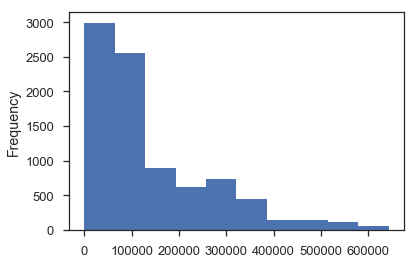

```python
#Below code will plot a histogram of OpenInterest for the data Oil

oil.OpenInterest.plot('hist')
```

#### Since the data is very large, it takes kernel a lot of time to plot graphs so we will reduce the data size while plotting graphs.

### We will now observe the top 100 Open and Final values for Oil using swarmplot.

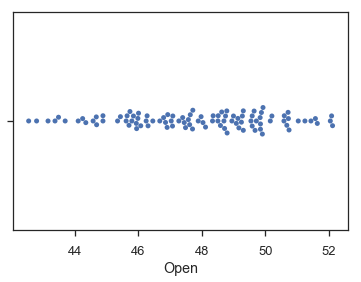

```python
#We create a different data frame oil_hundred which will consist of only top 100 values and then plot it.

oil_hundred = oil.head(100)

sns.swarmplot(x="Open", data=oil_hundred)
```

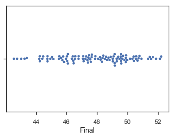

```python
#Now we plot a swarplot for top 100 Final values of Oil.

sns.swarmplot(x="Final", data=oil_hundred)
```

### We will now observe the difference between top 10 High and Low values for Oil

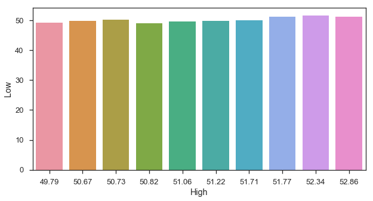

```python
#We set the size of the figure to pixels 10x10 using figsize function

f,ax=plt.subplots(figsize=(10,5))

#We again create a new data frame of top 10 values of Oil as oil_ten

oil_ten = oil.head(10)

#Now we will plot the High and Low values

sns.barplot(x="High", y="Low", data=oil_ten)
```

### Now we will observe the top 200 Last values of Oil using a violin plot

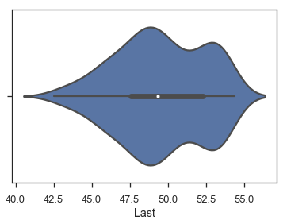

```python
#First we create a data frame of top 200 values

oil_two_hundred = oil.head(200)

#Now we plot the violin plot of column Last

sns.violinplot(x="Last", data=oil_two_hundred)
```

#### We now plot a point graph between top 10 Open and Final values for Oil

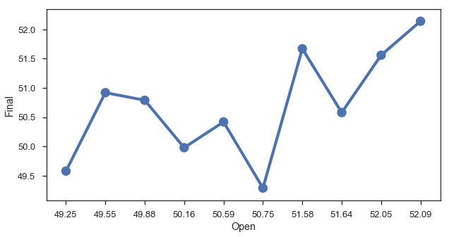

```python
f,ax=plt.subplots(figsize=(10,5))

sns.pointplot(x="Open", y="Final", data=oil_ten)
```